# Workshop: Plumber APIs in R

13.06.2019

## Agenda:

- Intro HTTP APIs und Plumber
- Erstellen einer Plumber API aus Shiny App
- Publishen der API zu RStudio Connect
- Aufrufen des Modells via Httr / Shiny

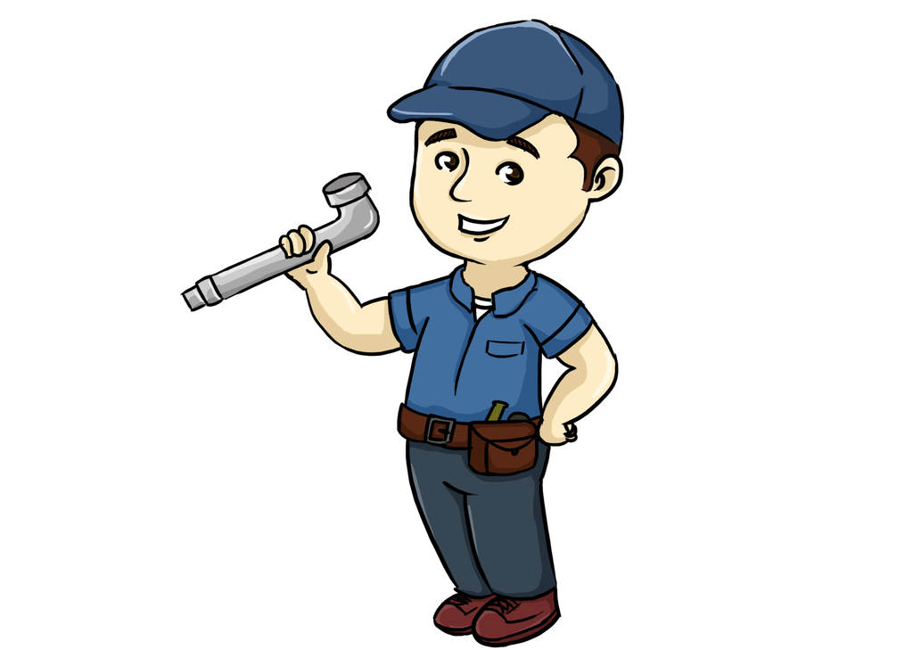

## HTTP (REST) APIs

- Machine to machine (M2M) Kommunikation
- Programmatisch konsumiert
- Maschinenlesbare austauschformate (JSON, XML)
- Von den meisten Programmiersprachen unterstützt

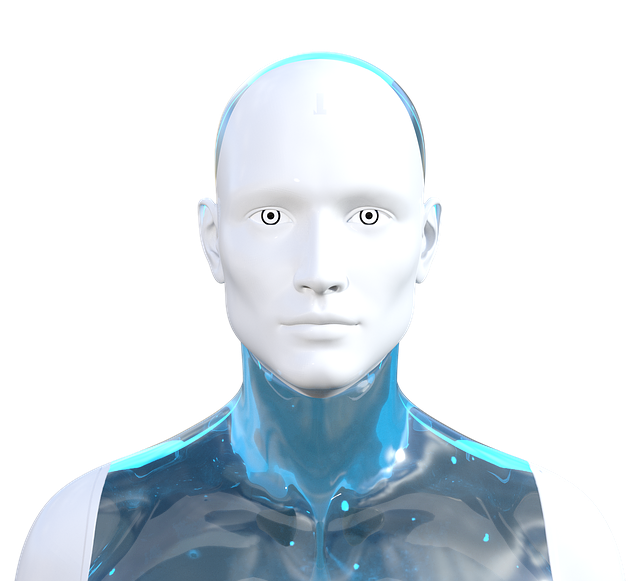

## Use Case Shiny

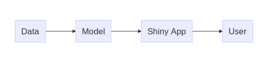

Vermitteln von Informationen an Menschen

## Use Case Plumber

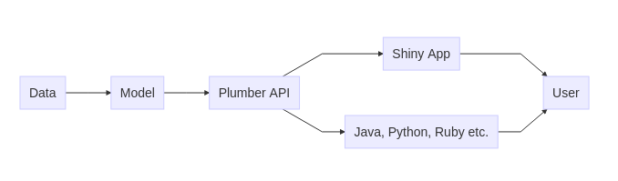

Kommunikation zwischen Maschinen

## Plumber R-Paket

- Open Source R Package
- Auf CRAN (Comprehensive R Archive Network) verfügbar
- Einfaches Erzeugen von APIs aus R Code mit speziellen Kommentaren

[figure not shown]

## OpenAPI (swagger)

- Standardisierte Spezifikation von REST Schnittstellen
- Vollständige Dokumentation einer API mit Swagger UI
- Voll unterstützt von Plumber

[figure not shown]

## Hosting von Plumber APIs

- RStudio Connect
  - Load Balancing / Skalierung
  - Zugriffskontrolle
  - API Keys
- Docker
- Digitalocean
- Linux Server (systemd, Rscript)

## Hands On: REST API mit Plumber

[figure not shown]

## Erstellung eines einfachen Modells

```r
# Build simple model from mtcars dataset

## ---- cars-model
# Model ---- (insert fancy model here)
cars_model <- lm(mpg ~ cyl + hp,
                 data = mtcars)

# Save model ----
saveRDS(cars_model, here::here("R", "model-api", "cars-model.rds"))
```

Erstellen und Speichern eines einfachen linearen Modells

## API Setup

```r
library(plumber)

# Load model
# Depending on model size, this can be a fairly expensive operation
cars_model <- readRDS("cars-model.rds")

#* @apiTitle mtcars model API
#* @apiDescription Endpoints for working with mtcars dataset model
```

Laden des R-Pakets `plumber` und des Modells `cars_model` in die globale Umgebung

## Filtern des Requests

```r
#* Log some information about the incoming request
#* @filter logger
function(req){
  cat(as.character(Sys.time()), "-",
      req$REQUEST_METHOD, req$PATH_INFO, "-",
      req$HTTP_USER_AGENT, "@", req$REMOTE_ADDR, "\n")
  forward()
}
```

Logging lässt sich via [Filter](https://www.rplumber.io/docs/routing-and-input.html#filters) realisieren

## Endpoints

```r
#* Submit data and get a prediction in return
#* @post /predict
function(req, res) {
  data <- tryCatch(jsonlite::parse_json(req$postBody, simplifyVector = TRUE),
                   error = function(e) NULL)
  if (is.null(data)) {
    res$status <- 400
    return(list(error = "No data submitted"))
  }

  predict(cars_model, data)
}
```

Konvertieren der JSON-Daten aus `req$postBody` in einen `data.frame` nach Überprüfung auf validen JSON `POST` Request. Anschließend Ausgabe des MPG Wertes als JSON anhand des Modells aus `cars-model.R`

## Config Paket

```r
default:
  base_url: "localhost:5762"
rsconnect:
  base_url: "http:/ec2-<Public-EC2-IP>/rsconnect"
```

Ablegen der aktuellen URL des Connect Servers

## Deployment der API

```r
rsconnect::deployAPI(
    api = ".",
    # server = "{server}",     # <<- edit this line if necessary
    # account = "{account}",   # <<- edit this line if necessary
    appTitle = "plumber_model_api",
    forceUpdate = TRUE
  ))
```

## Konsumieren der Plumber API mit Shiny

[figure not shown]

## HTTP Request senden

```r
# Make API request
    api_res <- httr::POST(url = paste0(base_url, "/predict"),
                          body = reactive_values$data,
                          encode = "json")
```

POST Request mit JSON Daten aus Shiny

## Verarbeiten der JSON Daten

```r
# Extract JSON from API response
reactive_values$predicted_values <- httr::content(api_res, as = "text", encoding = "UTF-8")
...
#Add predicted values to data
if (!"predicted_mpg" %in% names(reactive_values$data)) {
  reactive_values$data <- cbind(reactive_values$data,
  predicted_mpg = as.numeric(jsonlite::fromJSON(reactive_values$predicted_values)))
  }
```

Weiterverarbeiten der Daten mit `jsonlite`

## Rendern des Outputs in Shiny

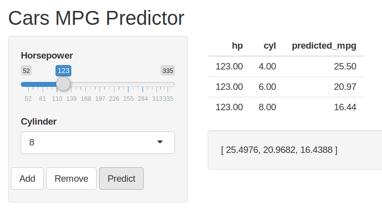

That’s it!

## Fragen?

Plumber Webseite und Dokumentation: rplumber.io

Folien und R-Code: [https://github.com/eodaGmbH/ready_for_production](https://github.com/eodaGmbH/ready_for_production/tree/master/Plumber_APIs_in_R)

Quell-Repo plumber-model: github.com/sol-eng/plumber-model

Bei Interesse an Data Science Projekten, analytic infrastructure consulting und YUNA: eoda.de